# GRF Scoring for Binary Outcomes: Methodology and Simulation Study

- Show All Code
- Hide All Code
- View Source

Aligning Doubly Robust CATE Estimates with ForestSearch Subgroup Identification

Author

Larry F. Leon

Published

April 7, 2026

# 1 Introduction

## 1.1 GRF and the Conditional Average Treatment Effect

Generalized Random Forests (GRF; Athey, Tibshirani, and Wager, 2019) estimate the Conditional Average Treatment Effect (CATE):

$$\tau(x) = E[Y_i(1) - Y_i(0) \mid X_i = x]$$

For a binary treatment $W \in \{0, 1\}$ and covariates $X$, GRF’s `causal_forest()` constructs adaptive neighborhood weights $\alpha_i(x)$ via a forest trained to maximize heterogeneity in treatment effects. The CATE is then estimated by a locally weighted residual-on-residual regression (Robinson, 1988):

$$\hat{\tau}(x) = \text{lm}\Big(
Y_i - \hat{m}^{(-i)}(X_i) \sim W_i - \hat{e}^{(-i)}(X_i),
\; \text{weights} = \alpha_i(x)
\Big)$$

where $\hat{m}(x) = E[Y \mid X = x]$ is the conditional mean and $\hat{e}(x) = P(W = 1 \mid X = x)$ is the propensity score.

## 1.2 Doubly Robust Scores

The `policytree` package computes doubly robust (DR) scores from a fitted causal forest. For a binary treatment, the function `double_robust_scores()` returns an $n \times 2$ matrix $[\Gamma_0, \Gamma_1]$ where each column is a doubly robust estimate of the expected potential outcome under that action:

$$\Gamma_{ia} = \hat{\mu}_a(X_i) + \frac{1}{\hat{e}_a(X_i)}
\big(Y_i - \hat{\mu}_a(X_i)\big) \cdot \mathbb{1}(A_i = a)$$

- Column 1 ($\Gamma_0$): DR estimate of $E[Y(0) \mid X]$ (control reward)
- Column 2 ($\Gamma_1$): DR estimate of $E[Y(1) \mid X]$ (treated reward)

The CATE for individual $i$ is $\Gamma_{i1} - \Gamma_{i0}$.

## 1.3 Policy Trees and Subgroup Selection

A `policy_tree` maximizes the sum of rewards across all observations by finding splits that assign each individual to the action with the highest DR score. For a binary treatment:

- `predict(tree, X) == 1` $\Rightarrow$ recommend control ($\Gamma_0 > \Gamma_1$, treatment hurts)
- `predict(tree, X) == 2` $\Rightarrow$ recommend treatment ($\Gamma_1 > \Gamma_0$, treatment helps)

This means individuals assigned to action 1 form a subgroup where the estimated CATE is negative — treatment is harmful.

## 1.4 Score Convention: Survival vs Binary GRF

In `forestsearch`, GRF standalone analysis identifies a “harm” subgroup and computes a score for selecting among candidate subgroups (across tree depths). The convention must align between survival and binary endpoints.

**Survival GRF** (`grf.subg.harm.survival`, via `grf_helpers.R`):

The score per leaf node is:
$$\text{diff} = \overline{\Gamma}_0^{\text{leaf}} - \overline{\Gamma}_1^{\text{leaf}}
= -\widehat{\text{CATE}}_{\text{leaf}}$$

The leaf with `which.max(diff)` is selected — where treatment hurts most. The threshold `dmin.grf` is compared to this **absolute** harm magnitude.

**Binary GRF** (`grf.subg.harm.glm`, revised):

The score is now aligned:
$$\text{score} = -\widehat{\text{CATE}}_{\text{sg}}
= \overline{\Gamma}_0^{\text{sg}} - \overline{\Gamma}_1^{\text{sg}}$$

where $\text{sg}$ is the set of individuals assigned to `leaf_action == 1` (recommend control).

**Previously**, the score was computed as a relative difference: $\text{score} = (\overline{\Gamma}_0 - \overline{\Gamma}_1)_{\text{sg}} - (\overline{\Gamma}_0 - \overline{\Gamma}_1)_{\text{all}}$, which measured excess harm relative to the population average rather than the absolute treatment effect contrast within the subgroup. This gave `dmin.grf` a different interpretation from the survival GRF and could miss subgroups with large absolute harm but small differential.

## 1.5 Scope of This Document

This document:

1. Validates the revised scoring on ACTG175-based simulations with binary outcomes (CD4 improvement).
2. Examines GRF standalone CATE accuracy and subgroup identification.
3. Compares GRF standalone with ForestSearch (FS) under the same DGM.

# 2 Data Preparation

```r
library(forestsearch)
library(survival)
library(speff2trial)
library(data.table)
library(gt)
library(ggplot2)
library(doFuture)
library(foreach)
library(grf)

timings <- list()
```

```r
t0 <- proc.time()[3]

actg_df <- subset(speff2trial::ACTG175, arms %in% actg_arms)
actg_df$id <- seq_len(nrow(actg_df))
actg_df$treat_orig <- ifelse(actg_df$arms == 1L, 1L, 0L)
actg_df$treat <- 1L - actg_df$treat_orig
actg_df$y_binary <- as.integer(actg_df$cd420 > actg_df$cd40)
actg_df <- actg_df[!is.na(actg_df$cd420), ]

actg_df$z1  <- as.factor(ifelse(actg_df$age > actg_age_cut, 1L, 0L))
actg_df$z2  <- as.factor(ifelse(actg_df$preanti <= actg_preanti_cut, 1L, 0L))
actg_df$z3  <- as.factor(ifelse(actg_df$wtkg <= 75, 1L, 0L))
actg_df$z4  <- as.factor(ifelse(
  actg_df$karnof <= median(actg_df$karnof), 1L, 0L))
actg_df$z5  <- as.factor(ifelse(
  actg_df$cd40 <= median(actg_df$cd40), 1L, 0L))
actg_df$z6  <- as.factor(ifelse(
  actg_df$cd80 <= median(actg_df$cd80), 1L, 0L))
actg_df$z7  <- as.factor(actg_df$hemo)
actg_df$z8  <- as.factor(actg_df$homo)
actg_df$z9  <- as.factor(actg_df$drugs)
actg_df$z10 <- as.factor(actg_df$race)
actg_df$z11 <- as.factor(actg_df$gender)
actg_df$z12 <- as.factor(actg_df$symptom)

actg_df$flag_harm_ref <- as.integer(actg_df$z1 == 1 & actg_df$z2 == 1)

cat(sprintf("N = %d, response rate = %.1f%%\n",
    nrow(actg_df), 100 * mean(actg_df$y_binary)))
```

```
#> N = 1083, response rate = 60.3%
```

```r
cat(sprintf("Q prevalence: %.1f%%\n",
    100 * mean(actg_df$flag_harm_ref)))
```

```
#> Q prevalence: 35.3%
```

```r
timings$data_prep <- proc.time()[3] - t0
```

# 3 DGM Construction

```r
t0 <- proc.time()[3]

dgm_calibrated <- calibrate_glm_interaction(
  data          = actg_df,
  factor_vars   = dgm_factor_vars,
  outcome_var   = "y_binary",
  treatment_var = "treat",
  target_effect = cal_target_or,
  outcome_type  = "binary",
  effect_measure = "OR",
  subgroup_vars = dgm_subgroup_vars,
  subgroup_cuts = dgm_subgroup_cuts,
  k_inter_range = cal_k_grid_range,
  grid_step     = cal_grid_step,
  n_super       = dgm_n_super,
  seed          = sim_seed,
  verbose       = TRUE
)
```

```
#> Calibrating: target OR = 2.000
#>   Grid: 0.00 to 3.00 by 0.050 (61 values)
#>   Best: k_inter = 1.150 -> Effect(Q) = 2.0071 (target: 2.000)
#> === generate_glm_dgm() ===
#>   outcome_type:   binary
#>   effect_measure: OR
#>   model:          alt
#>   k_inter:        1.150
#>   n_super:        5000
#>   n observations: 1083
#>   Dropped single-level factors: z4
#>
#> === Subgroup Definitions ===
#>    z1 == 1
#>     Proportion in subgroup: 0.488
#>    z2 == 1
#>     Proportion in subgroup: 0.75
#>
#> Overall subgroup (all conditions met):
#>   Size: 382 out of 1083
#>   Proportion: 0.353
#>
#> Baseline GLM fit (no interaction):
#>   AIC: 1411.2
#>   Treatment coefficient: -0.4269 (OR = 0.653)
#>   Interaction shift (k_inter): 1.1500
#>
#> === DGM Summary ===
#>   Effect(Q):   2.0071  (OR)
#>   Effect(Qc):  0.6681  (OR)
#>   Effect(ITT): 0.9186  (OR)
#>   Subgroup prevalence: 34.5%
#>
#> Calibration complete: k_inter = 1.150
#>   Effect(Q):   2.0071
#>   Effect(Qc):  0.6681
#>   Effect(ITT): 0.9186
```

```r
dgm_null <- generate_glm_dgm(
  data          = actg_df,
  factor_vars   = dgm_factor_vars,
  outcome_var   = "y_binary",
  treatment_var = "treat",
  outcome_type  = "binary",
  subgroup_vars = dgm_subgroup_vars,
  subgroup_cuts = dgm_subgroup_cuts,
  model         = "null",
  n_super       = dgm_n_super,
  seed          = sim_seed,
  verbose       = TRUE
)
```

```
#> === generate_glm_dgm() ===
#>   outcome_type:   binary
#>   effect_measure: OR
#>   model:          null
#>   k_inter:        0.000
#>   n_super:        5000
#>   n observations: 1083
#>   Dropped single-level factors: z4
#>
#> === Subgroup Definitions ===
#>    z1 == 1
#>     Proportion in subgroup: 0.488
#>    z2 == 1
#>     Proportion in subgroup: 0.75
#>
#> Overall subgroup (all conditions met):
#>   Size: 382 out of 1083
#>   Proportion: 0.353
#>
#> Baseline GLM fit (no interaction):
#>   AIC: 1411.2
#>   Treatment coefficient: -0.4269 (OR = 0.653)
#>   Interaction shift (k_inter): 0.0000 (null model: forced to 0)
#>
#> === DGM Summary ===
#>   Effect(Q):   0.6653  (OR)
#>   Effect(Qc):  0.6681  (OR)
#>   Effect(ITT): 0.6678  (OR)
#>   Subgroup prevalence: 34.5%
```

```r
cat("\n=== Alternative DGM ===\n")
```

```
#>
#> === Alternative DGM ===
```

```r
cat("  OR(Q):  ", round(dgm_calibrated$hazard_ratios$harm_subgroup, 3), "\n")
```

```
#>   OR(Q):   2.007
```

```r
cat("  OR(Qc): ", round(dgm_calibrated$hazard_ratios$no_harm_subgroup, 3), "\n")
```

```
#>   OR(Qc):  0.668
```

```r
cat("  OR(ITT):", round(dgm_calibrated$hazard_ratios$overall, 3), "\n")
```

```
#>   OR(ITT): 0.919
```

```r
cat("  k_inter:", dgm_calibrated$model_params$k_inter, "\n")
```

```
#>   k_inter: 1.15
```

```r
cat("\n=== Null DGM ===\n")
```

```
#>
#> === Null DGM ===
```

```r
cat("  OR(ITT):", round(dgm_null$hazard_ratios$overall, 3), "\n")
```

```
#>   OR(ITT): 0.668
```

```r
timings$dgm <- proc.time()[3] - t0
```

# 4 Single-Data GRF Analysis

Before simulations, run GRF standalone on the observed ACTG175 data to verify the revised scoring produces interpretable results.

```r
t0 <- proc.time()[3]

confounders_actg <- dgm_calibrated$factor_vars

grf_result <- grf.subg.harm.glm(
  data             = actg_df,
  confounders.name = confounders_actg,
  outcome.name     = "y_binary",
  treat.name       = "treat",
  id.name          = "id",
  outcome_type     = "binary",
  effect_measure   = "OR",
  n.min            = grf_n_min,
  dmin.grf         = grf_dmin,
  maxdepth         = grf_maxdepth,
  RCT              = TRUE,
  sg.criterion     = grf_sg_criterion,
  details          = TRUE,
  seedit           = fs_seedit
)

cat("\n=== GRF Single-Data Result ===\n")
```

```
#>
#> === GRF Single-Data Result ===
```

```r
if (!is.null(grf_result$sg.harm.id)) {
  cat("Subgroup: ", paste(grf_result$sg.harm.id, collapse = " & "), "\n")
  cat(sprintf("  CATE(H):  %.4f\n", grf_result$cate_sg))
  cat(sprintf("  CATE(Hc): %.4f\n", grf_result$cate_sgc))

  in_H  <- grf_result$data$treat.recommend == 0
  in_Hc <- grf_result$data$treat.recommend == 1
  cat(sprintf("  n(H) = %d (%.1f%%),  n(Hc) = %d\n",
      sum(in_H), 100 * mean(in_H), sum(in_Hc)))

  # Classification against true Q
  true_Q <- actg_df$flag_harm_ref == 1
  tp <- sum(in_H & true_Q); fp <- sum(in_H & !true_Q)
  fn <- sum(!in_H & true_Q); tn <- sum(!in_H & !true_Q)
  cat(sprintf("\n  Classification vs true Q:\n"))
  cat(sprintf("    TP=%d FP=%d FN=%d TN=%d\n", tp, fp, fn, tn))
  cat(sprintf("    Sens=%.3f Spec=%.3f PPV=%.3f\n",
      tp/(tp+fn), tn/(tn+fp), tp/(tp+fp)))
} else {
  cat("No subgroup identified.\n")
}
```

```
#> Subgroup:  z2 <= 0 & z1 <= 0
#>   CATE(H):  -0.1240
#>   CATE(Hc): 0.1138
#>   n(H) = 959 (88.6%),  n(Hc) = 124
#>
#>   Classification vs true Q:
#>     TP=382 FP=577 FN=0 TN=124
#>     Sens=1.000 Spec=0.177 PPV=0.398
```

```r
timings$single_grf <- proc.time()[3] - t0
```

## 4.1 GRF CATE Distribution

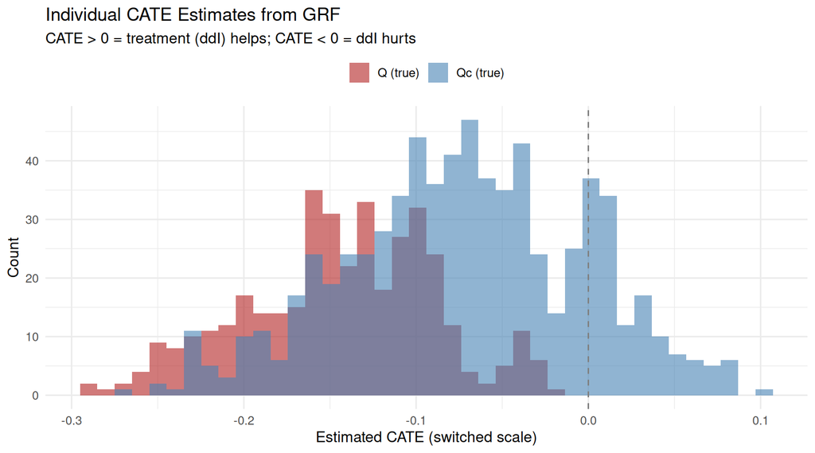

Distribution of GRF-estimated CATE on observed ACTG175 data.

```r
# Extract individual CATE predictions from the causal forest
tau_hat <- predict(grf_result$cs_forest)$predictions

cate_df <- data.frame(
  cate = tau_hat,
  group = ifelse(actg_df$flag_harm_ref == 1, "Q (true)", "Qc (true)")
)

ggplot(cate_df, aes(x = cate, fill = group)) +
  geom_histogram(bins = 40, alpha = 0.6, position = "identity") +
  geom_vline(xintercept = 0, linetype = "dashed", colour = "grey50") +
  scale_fill_manual(values = c("Q (true)" = "firebrick",
                                "Qc (true)" = "steelblue")) +
  labs(x = "Estimated CATE (switched scale)",
       y = "Count",
       title = "Individual CATE Estimates from GRF",
       subtitle = "CATE > 0 = treatment (ddI) helps; CATE < 0 = ddI hurts",
       fill = NULL) +
  theme_minimal(base_size = 12) +
  theme(legend.position = "top")
```

# 5 Simulation Study

## 5.1 Design

The simulation evaluates GRF standalone and ForestSearch under the ACTG175 binary DGM with OR(Q) = 2 on the switched treatment scale.

For each replicate:

1. Simulate $n =$ 1000 observations from the calibrated (alt) or null DGM via `simulate_from_glm_dgm()`.
2. Run GRF standalone (`grf.subg.harm.glm()`) with the revised scoring.
3. Run ForestSearch (`forestsearch()`) with `outcome_type = "binary"`.
4. Record: detection (any subgroup found), CATE estimates, classification metrics (sensitivity, specificity, PPV).

## 5.2 Setup

```r
plan(multisession, workers = n_workers)
cat("Using", n_workers, "parallel workers\n")
```

```
#> Using 120 parallel workers
```

## 5.3 Simulation Function

```r
run_single_sim <- function(sim_id, dgm, confounders, run_grf_standalone,
                            grf_params, fs_params_list) {
  # Simulate data
  df_sim <- simulate_from_glm_dgm(dgm, n = sim_n_sample,
                                    seed = sim_seed + sim_id)

  results <- list()

  # -- GRF standalone ----------------------------------------------------------
  if (run_grf_standalone) {
    grf_res <- tryCatch({
      grf.subg.harm.glm(
        data             = df_sim,
        confounders.name = confounders,
        outcome.name     = "y_sim",
        treat.name       = "treat_sim",
        id.name          = "id",
        outcome_type     = "binary",
        effect_measure   = "OR",
        n.min            = grf_params$n.min,
        dmin.grf         = grf_params$dmin.grf,
        maxdepth         = grf_params$maxdepth,
        RCT              = TRUE,
        sg.criterion     = grf_params$sg.criterion,
        seedit           = grf_params$seedit
      )
    }, error = function(e) NULL)

    grf_detected <- !is.null(grf_res) && !is.null(grf_res$sg.harm.id)

    if (grf_detected) {
      in_H  <- grf_res$data$treat.recommend == 0
      true_Q <- df_sim$flag_harm == 1

      tp <- sum(in_H & true_Q); fp <- sum(in_H & !true_Q)
      fn <- sum(!in_H & true_Q); tn <- sum(!in_H & !true_Q)

      results[["GRF"]] <- data.frame(
        sim_id   = sim_id,
        analysis = "GRF",
        any.H    = 1L,
        n_H      = sum(in_H),
        cate_H   = grf_res$cate_sg,
        cate_Hc  = grf_res$cate_sgc,
        sens     = tp / max(tp + fn, 1),
        spec     = tn / max(tn + fp, 1),
        ppv      = tp / max(tp + fp, 1),
        npv      = tn / max(tn + fn, 1),
        stringsAsFactors = FALSE
      )
    } else {
      results[["GRF"]] <- data.frame(
        sim_id = sim_id, analysis = "GRF", any.H = 0L,
        n_H = 0L, cate_H = NA_real_, cate_Hc = NA_real_,
        sens = NA_real_, spec = NA_real_,
        ppv = NA_real_, npv = NA_real_,
        stringsAsFactors = FALSE
      )
    }
  }

  # -- ForestSearch ------------------------------------------------------------
  fs_res <- tryCatch({
    suppressWarnings(forestsearch(
      df.analysis      = df_sim,
      confounders.name = confounders,
      outcome.name     = "y_sim",
      event.name       = "y_sim",
      treat.name       = "treat_sim",
      id.name          = "id",
      outcome_type     = fs_params_list$outcome_type,
      effect_measure   = fs_params_list$effect_measure,
      seedit           = fs_params_list$seedit,
      n.min            = fs_params_list$n.min,
      d0.min           = fs_params_list$d0.min,
      d1.min           = fs_params_list$d1.min,
      hr.threshold     = fs_params_list$hr.threshold,
      hr.consistency   = fs_params_list$hr.consistency,
      pconsistency.threshold = fs_params_list$pconsistency.threshold,
      fs.splits        = fs_params_list$fs.splits,
      maxk             = fs_params_list$maxk,
      use_lasso        = FALSE,
      use_grf          = TRUE,
      is.RCT           = TRUE,
      vi.grf.min       = fs_params_list$vi.grf.min,
      details          = FALSE,
      quiet            = TRUE,
      parallel_args    = list(plan = "sequential", workers = 1,
                              show_message = FALSE)
    ))
  }, error = function(e) NULL)

  fs_detected <- !is.null(fs_res) && !is.null(fs_res$grp.consistency) &&
    !is.null(fs_res$grp.consistency$sg.harm.id) &&
    length(fs_res$grp.consistency$sg.harm.id) > 0 &&
    !all(is.na(fs_res$grp.consistency$sg.harm.id))

  if (fs_detected) {
    df_est <- fs_res$df.est
    in_H   <- df_est$treat.recommend == 0
    true_Q <- df_sim$flag_harm == 1

    tp <- sum(in_H & true_Q); fp <- sum(in_H & !true_Q)
    fn <- sum(!in_H & true_Q); tn <- sum(!in_H & !true_Q)

    # Compute OR in identified subgroup
    fit_H <- tryCatch(
      glm(y_sim ~ treat_sim, data = df_est[in_H, ], family = binomial),
      error = function(e) NULL
    )
    or_H <- if (!is.null(fit_H)) exp(coef(fit_H)["treat_sim"]) else NA_real_

    results[["FS"]] <- data.frame(
      sim_id   = sim_id,
      analysis = "FS",
      any.H    = 1L,
      n_H      = sum(in_H),
      cate_H   = NA_real_,
      cate_Hc  = NA_real_,
      sens     = tp / max(tp + fn, 1),
      spec     = tn / max(tn + fp, 1),
      ppv      = tp / max(tp + fp, 1),
      npv      = tn / max(tn + fn, 1),
      stringsAsFactors = FALSE
    )
  } else {
    results[["FS"]] <- data.frame(
      sim_id = sim_id, analysis = "FS", any.H = 0L,
      n_H = 0L, cate_H = NA_real_, cate_Hc = NA_real_,
      sens = NA_real_, spec = NA_real_,
      ppv = NA_real_, npv = NA_real_,
      stringsAsFactors = FALSE
    )
  }

  do.call(rbind, results)
}
```

## 5.4 Alternative Hypothesis

```r
cat("Running", nsims, "simulations under H1...\n")
```

```
#> Running 200 simulations under H1...
```

```r
t0 <- proc.time()[3]

grf_p <- list(n.min = grf_n_min, dmin.grf = grf_dmin,
              maxdepth = grf_maxdepth, sg.criterion = grf_sg_criterion,
              seedit = fs_seedit)

fs_p <- list(
  outcome_type = "binary", effect_measure = "OR",
  hr.threshold = fs_or_threshold, hr.consistency = fs_or_consistency,
  pconsistency.threshold = fs_pconsistency, fs.splits = fs_splits,
  n.min = fs_n_min, d0.min = fs_d0_min, d1.min = fs_d1_min,
  maxk = fs_maxk, vi.grf.min = fs_vi_grf_min, seedit = fs_seedit
)

results_alt <- foreach(
  sim = seq_len(nsims),
  .combine = rbind,
  .errorhandling = "remove",
  .options.future = list(
    packages = c("forestsearch", "grf", "policytree", "data.table"),
    seed = TRUE
  )
) %dofuture% {
  future::plan("sequential")
  run_single_sim(
    sim_id = sim, dgm = dgm_calibrated,
    confounders = dgm_calibrated$factor_vars,
    run_grf_standalone = TRUE,
    grf_params = grf_p, fs_params_list = fs_p
  )
}

timings$sims_alt <- proc.time()[3] - t0
cat("Completed in", round(timings$sims_alt / 60, 1), "minutes\n")
```

```
#> Completed in 2.8 minutes
```

```r
cat("Results:", nrow(results_alt), "rows\n")
```

```
#> Results: 400 rows
```

## 5.5 Null Hypothesis

```r
cat("Running", nsims, "simulations under H0...\n")
```

```
#> Running 200 simulations under H0...
```

```r
t0 <- proc.time()[3]

results_null <- foreach(
  sim = seq_len(nsims),
  .combine = rbind,
  .errorhandling = "remove",
  .options.future = list(
    packages = c("forestsearch", "grf", "policytree", "data.table"),
    seed = TRUE
  )
) %dofuture% {
  future::plan("sequential")
  run_single_sim(
    sim_id = sim, dgm = dgm_null,
    confounders = dgm_null$factor_vars,
    run_grf_standalone = TRUE,
    grf_params = grf_p, fs_params_list = fs_p
  )
}

timings$sims_null <- proc.time()[3] - t0
cat("Completed in", round(timings$sims_null / 60, 1), "minutes\n")
```

```
#> Completed in 0.3 minutes
```

```r
plan(sequential)
```

# 6 Results

```r
results_alt_dt  <- as.data.table(results_alt)
results_null_dt <- as.data.table(results_null)

summarize_method <- function(dt, method_name) {
  sub <- dt[analysis == method_name]
  n_sims <- nrow(sub)
  det <- mean(sub$any.H)
  det_sims <- sub[any.H == 1]

  list(
    method    = method_name,
    n_sims    = n_sims,
    detection = det,
    mean_sens = if (nrow(det_sims) > 0) mean(det_sims$sens, na.rm = TRUE) else NA,
    mean_spec = if (nrow(det_sims) > 0) mean(det_sims$spec, na.rm = TRUE) else NA,
    mean_ppv  = if (nrow(det_sims) > 0) mean(det_sims$ppv, na.rm = TRUE) else NA,
    mean_n_H  = if (nrow(det_sims) > 0) mean(det_sims$n_H, na.rm = TRUE) else NA,
    mean_cate_H  = if (nrow(det_sims) > 0) mean(det_sims$cate_H, na.rm = TRUE) else NA,
    mean_cate_Hc = if (nrow(det_sims) > 0) mean(det_sims$cate_Hc, na.rm = TRUE) else NA
  )
}
```

## 6.1 Detection and Classification Under H1

```r
alt_grf <- summarize_method(results_alt_dt, "GRF")
alt_fs  <- summarize_method(results_alt_dt, "FS")

alt_summary <- rbind(
  as.data.frame(alt_grf),
  as.data.frame(alt_fs)
)

gt(alt_summary) |>
  tab_header(
    title = "Operating Characteristics Under H1",
    subtitle = sprintf(
      "n = %d, %d sims, OR(Q) = %.2f (switched)",
      sim_n_sample, nsims,
      dgm_calibrated$hazard_ratios$harm_subgroup
    )
  ) |>
  fmt_percent(columns = c(detection, mean_sens, mean_spec, mean_ppv),
              decimals = 1, scale_values = TRUE) |>
  fmt_number(columns = c(mean_n_H, mean_cate_H, mean_cate_Hc),
             decimals = 2) |>
  cols_label(
    method = "Method",
    n_sims = "Sims",
    detection = "Detection",
    mean_sens = "Sensitivity",
    mean_spec = "Specificity",
    mean_ppv  = "PPV",
    mean_n_H  = "Mean n(H)",
    mean_cate_H  = "Mean CATE(H)",
    mean_cate_Hc = "Mean CATE(Hc)"
  )
```

Operating Characteristics Under H1

n = 1000, 200 sims, OR(Q) = 2.01 (switched)

| Method | Sims | Detection | Sensitivity | Specificity | PPV | Mean n(H) | Mean CATE(H) | Mean CATE(Hc) |
| --- | --- | --- | --- | --- | --- | --- | --- | --- |
| GRF | 200 | 100.0% | 8.2% | 24.6% | 5.2% | 522.33 | −0.13 | 0.10 |
| FS | 200 | 76.0% | 50.2% | 96.3% | 77.7% | 196.97 | NaN | NaN |

## 6.2 False Discovery Under H0

```r
null_grf <- summarize_method(results_null_dt, "GRF")
null_fs  <- summarize_method(results_null_dt, "FS")

null_summary <- rbind(
  as.data.frame(null_grf),
  as.data.frame(null_fs)
)

gt(null_summary) |>
  tab_header(
    title = "False Discovery Under H0",
    subtitle = sprintf("n = %d, %d sims", sim_n_sample, nsims)
  ) |>
  fmt_percent(columns = detection, decimals = 1, scale_values = TRUE) |>
  cols_label(
    method = "Method",
    n_sims = "Sims",
    detection = "FDR"
  ) |>
  cols_hide(c(mean_sens, mean_spec, mean_ppv, mean_n_H,
              mean_cate_H, mean_cate_Hc))
```

False Discovery Under H0

n = 1000, 200 sims

| Method | Sims | FDR |
| --- | --- | --- |
| GRF | 200 | 100.0% |
| FS | 200 | 3.5% |

## 6.3 GRF CATE Accuracy Under H1

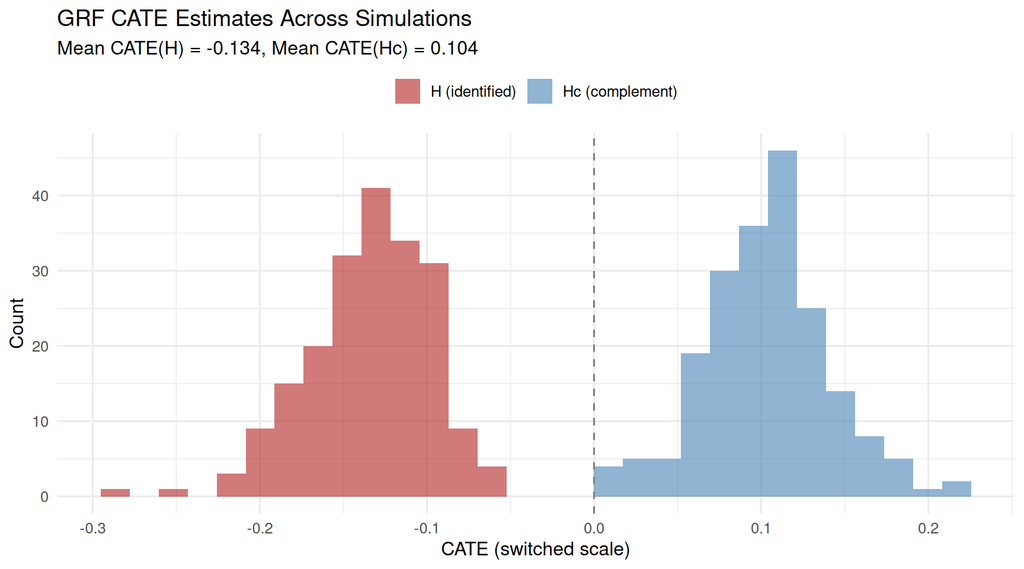

Distribution of GRF-estimated CATE(H) and CATE(Hc) across simulations (H1 only, detections only).

```r
grf_alt_det <- results_alt_dt[analysis == "GRF" & any.H == 1]

if (nrow(grf_alt_det) > 0) {
  cate_long <- rbind(
    data.frame(subgroup = "H (identified)",
               cate = grf_alt_det$cate_H),
    data.frame(subgroup = "Hc (complement)",
               cate = grf_alt_det$cate_Hc)
  )

  ggplot(cate_long, aes(x = cate, fill = subgroup)) +
    geom_histogram(bins = 30, alpha = 0.6, position = "identity") +
    geom_vline(xintercept = 0, linetype = "dashed", colour = "grey50") +
    scale_fill_manual(values = c("H (identified)" = "firebrick",
                                  "Hc (complement)" = "steelblue")) +
    labs(x = "CATE (switched scale)",
         y = "Count",
         title = "GRF CATE Estimates Across Simulations",
         subtitle = sprintf(
           "Mean CATE(H) = %.3f, Mean CATE(Hc) = %.3f",
           mean(grf_alt_det$cate_H, na.rm = TRUE),
           mean(grf_alt_det$cate_Hc, na.rm = TRUE)
         ),
         fill = NULL) +
    theme_minimal(base_size = 12) +
    theme(legend.position = "top")
} else {
  cat("No GRF detections under H1.\n")
}
```

## 6.4 Sensitivity Comparison

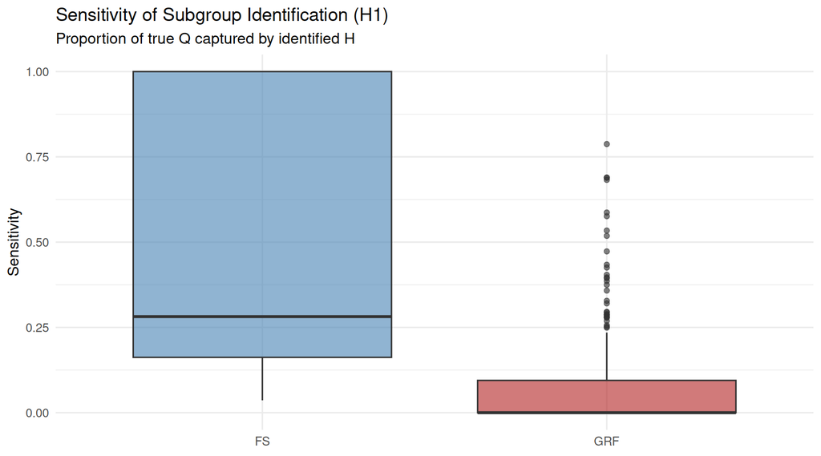

Sensitivity by method across simulations (H1 detections only).

```r
det_alt <- results_alt_dt[any.H == 1]

if (nrow(det_alt) > 0) {
  ggplot(det_alt, aes(x = analysis, y = sens, fill = analysis)) +
    geom_boxplot(alpha = 0.6) +
    scale_fill_manual(values = c("FS" = "steelblue", "GRF" = "firebrick")) +
    labs(x = NULL, y = "Sensitivity",
         title = "Sensitivity of Subgroup Identification (H1)",
         subtitle = "Proportion of true Q captured by identified H") +
    theme_minimal(base_size = 12) +
    theme(legend.position = "none")
} else {
  cat("No detections under H1.\n")
}
```

## 6.5 Classification Summary

```r
det_both <- results_alt_dt[any.H == 1, .(
  Detection = .N / nsims,
  Sensitivity = mean(sens, na.rm = TRUE),
  Specificity = mean(spec, na.rm = TRUE),
  PPV = mean(ppv, na.rm = TRUE),
  `Mean n(H)` = mean(n_H, na.rm = TRUE)
), by = analysis]

gt(det_both) |>
  tab_header(
    title = "Classification Comparison (H1, Detections Only)",
    subtitle = sprintf("n = %d, %d sims", sim_n_sample, nsims)
  ) |>
  fmt_number(columns = c(Detection, Sensitivity, Specificity, PPV),
             decimals = 3) |>
  fmt_number(columns = `Mean n(H)`, decimals = 0) |>
  cols_label(analysis = "Method")
```

Classification Comparison (H1, Detections Only)

n = 1000, 200 sims

| Method | Detection | Sensitivity | Specificity | PPV | Mean n(H) |
| --- | --- | --- | --- | --- | --- |
| GRF | 1.000 | 0.082 | 0.246 | 0.052 | 522 |
| FS | 0.760 | 0.502 | 0.963 | 0.777 | 197 |

# 7 Timing

```r
timings$total <- Reduce(`+`, timings)

timing_df <- data.frame(
  Step = names(timings),
  Seconds = round(unlist(timings), 1),
  Minutes = round(unlist(timings) / 60, 2)
)

gt(timing_df) |>
  tab_header(title = "Computation Timing") |>
  tab_style(
    style = cell_text(weight = "bold"),
    locations = cells_body(rows = Step == "total")
  )
```

Computation Timing

| Step | Seconds | Minutes |
| --- | --- | --- |
| data_prep | 0.0 | 0.00 |
| dgm | 1.3 | 0.02 |
| single_grf | 0.2 | 0.00 |
| sims_alt | 166.5 | 2.77 |
| sims_null | 20.2 | 0.34 |
| total | 188.3 | 3.14 |

# 8 Discussion

## 8.1 Key Findings

The revised GRF scoring aligns the binary endpoint GRF with the survival GRF convention:

- **Score = $-\widehat{\text{CATE}}_{\text{sg}}$**: the absolute negative treatment effect in the identified subgroup. Positive score means treatment hurts.
- **`dmin.grf`** now has a consistent interpretation across survival and binary: the minimum CATE magnitude required to declare a subgroup.
- The CATE estimates stored in the result object (`cate_sg`, `cate_sgc`) provide direct diagnostic information about the treatment effect contrast in each subgroup.

## 8.2 FS vs GRF Direction on Binary Improvement Outcomes

With Y = improvement and switched treatment (ddI = `treat`):

- **FS** searches for OR > threshold (ddI increases improvement for Q). FS’s identified H is where ddI **helps**.
- **GRF** assigns `treat.recommend = 0` to patients where $\hat{\tau}(x) < 0$ (ddI decreases improvement). GRF’s identified H is where ddI **hurts**.

Under the switched-treatment benefit-search framework, these two methods identify **complementary** subgroups: FS finds Q (benefit from combo) while GRF finds Qc (harmed by ddI). This is not a bug but a fundamental consequence of the OR scale: OR > 1 = treatment helps, whereas GRF’s CATE < 0 = treatment hurts.

For survival endpoints, this is not an issue because HR > 1 = treatment hurts (more events), which aligns with GRF’s CATE < 0 direction.

## 8.3 Implications for `run_grf = TRUE` in Binary Simulations

Setting `run_grf = FALSE` in the binary simulation document remains appropriate until a decision is made on how to present the complementary GRF results. Three options remain open:

1. Report FS and GRF as complementary (FS finds Q, GRF finds Qc).
2. Flip GRF’s subgroup selection for improvement outcomes.
3. Swap labels at the reporting level when `subgroup_notation = "benefit"`.